# HW2_Harshita_DA

```python
import pandas as pd
import numpy as np
import matplotlib.pyplot as plt
import seaborn as sb
from sklearn.preprocessing import OneHotEncoder
from sklearn.preprocessing import LabelEncoder
from sklearn.cluster import KMeans
from scipy.cluster.hierarchy import ward, dendrogram
from scipy.spatial import distance_matrix
from sklearn.preprocessing import MinMaxScaler
from sklearn.tree import DecisionTreeClassifier
from sklearn.model_selection import train_test_split, GridSearchCV
from sklearn import metrics
from sklearn.pipeline import Pipeline
from sklearn.compose import ColumnTransformer
from sklearn.model_selection import train_test_split
from sklearn.metrics import fowlkes_mallows_score
from sklearn.cluster import AgglomerativeClustering
```

### Exploratory Data Analysis

The describe() function provides descriptive statistics summary of all numeric columns in dataframe

```python
csv_data = pd.read_csv('Weather Forecast Training.csv')
csv_data.describe()
```

|  | MinTemp | MaxTemp | Rainfall | Evaporation | Sunshine | WindGustSpeed | WindSpeed | Humidity | Pressure | Cloud | Temp |
| --- | --- | --- | --- | --- | --- | --- | --- | --- | --- | --- | --- |
| count | 51694.000000 | 51849.000000 | 51231.000000 | 29425.000000 | 27103.000000 | 48407.000000 | 50954.000000 | 50549.000000 | 46912.000000 | 31848.000000 | 50915.000000 |
| mean | 12.549174 | 22.512698 | 3.639494 | 5.177570 | 6.530580 | 42.003016 | 19.092299 | 57.432214 | 1014.273338 | 5.175647 | 20.845623 |
| std | 6.376746 | 7.113064 | 11.009628 | 4.017662 | 3.946561 | 14.627024 | 9.157505 | 21.833045 | 7.278733 | 2.632166 | 6.938471 |
| min | -8.000000 | -4.100000 | 0.000000 | 0.000000 | 0.000000 | 7.000000 | 0.000000 | 1.000000 | 977.100000 | 0.000000 | -4.400000 |
| 25% | 7.900000 | 17.200000 | 0.000000 | 2.400000 | 3.200000 | 31.000000 | 13.000000 | 42.000000 | 1009.300000 | 3.000000 | 15.700000 |
| 50% | 12.300000 | 21.800000 | 0.000000 | 4.400000 | 6.900000 | 39.000000 | 19.000000 | 58.000000 | 1014.200000 | 6.000000 | 20.200000 |
| 75% | 17.200000 | 27.500000 | 2.200000 | 7.000000 | 9.900000 | 50.000000 | 24.000000 | 73.000000 | 1019.200000 | 7.000000 | 25.600000 |
| max | 31.400000 | 47.000000 | 371.000000 | 77.300000 | 14.500000 | 135.000000 | 83.000000 | 100.000000 | 1037.800000 | 8.000000 | 46.100000 |

###### Get type of data present in columns

```python
csv_data.dtypes
```

```
Location          object
MinTemp          float64
MaxTemp          float64
Rainfall         float64
Evaporation      float64
Sunshine         float64
WindGustDir       object
WindGustSpeed    float64
WindDir           object
WindSpeed        float64
Humidity         float64
Pressure         float64
Cloud            float64
Temp             float64
RainToday         object
RainTomorrow      object
dtype: object
```

As we can see from the above results Location, WindGustDir, WindDir, RainToday and RainTommorow are the only categorical data columns others are numeric

###### Check if the numeric data present in dataframe are ordinal or numeric.

```python
#check if the float data are Ordinal or continous
for col in csv_data.columns:
    if csv_data[col].dtypes == np.float64:
        print(col, csv_data[col].nunique())
```

```
MinTemp 372
MaxTemp 484
Rainfall 599
Evaporation 270
Sunshine 144
WindGustSpeed 66
WindSpeed 40
Humidity 100
Pressure 523
Cloud 9
Temp 479
```

We can see from the above results that Cloud column contains Ordinal Data

###### Null Values for each column

```python
csv_data.isnull().sum()
```

```
Location             0
MinTemp            284
MaxTemp            129
Rainfall           747
Evaporation      22553
Sunshine         24875
WindGustDir       3598
WindGustSpeed     3571
WindDir           1513
WindSpeed         1024
Humidity          1429
Pressure          5066
Cloud            20130
Temp              1063
RainToday          747
RainTomorrow         0
dtype: int64
```

We decide a threshold value t. All the rows with Na values more than the threshold are dropped

```python
csv_data.isnull().sum(axis =1)
m = max(csv_data.isnull().sum(axis =1))
print(m)
for i in range(1, m+1):
    s = (csv_data.isnull().sum(axis =1)>i).sum()
    print(i , s)
```

```
14
1 25169
2 17699
3 6238
4 2419
5 1448
6 1029
7 775
8 501
9 391
10 117
11 37
12 12
13 3
14 0
```

```python
# about 10% of data has more than 3 columns as Nan thus its safe to remove these data points
csv_data=csv_data[(csv_data.isnull().sum(axis =1)<=3)]
```

```python
csv_data.isnull().sum()
```

```
Location             0
MinTemp             35
MaxTemp             12
Rainfall           176
Evaporation      16894
Sunshine         18867
WindGustDir       1571
WindGustSpeed     1563
WindDir            184
WindSpeed            8
Humidity           193
Pressure           348
Cloud            15006
Temp                12
RainToday          176
RainTomorrow         0
dtype: int64
```

```python
csv_data[['WindGustDir', 'WindDir','RainToday']] = csv_data[['WindGustDir','WindDir','RainToday']].fillna(value='Unknown')
```

### Data Vizualization and Interpolation of Missing Values

To interpolate missing values in the columns with numeric data it is important to decide if we should replace it with 0, median, or mean. But as data contains values for Temp, Rainfall etc it would be incorrect to do so as it will change the probability distribution of varibles. If the data contains outliers it would be better to replace it with median else mean would be good option

```
MinTemp -8.0 31.4
```

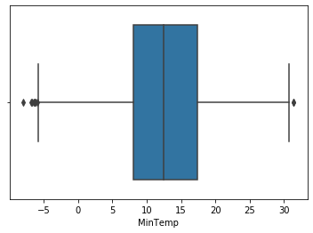

```
MaxTemp 4.1 47.0
```

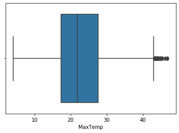

```
Rainfall 0.0 371.0
```

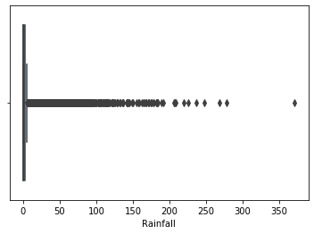

```
Evaporation nan nan
```

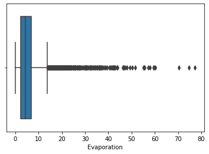

```
Sunshine nan nan
```

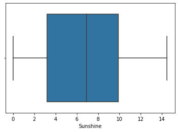

```
WindGustSpeed 7.0 135.0
```

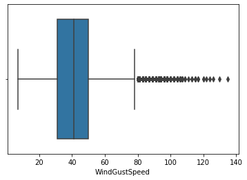

```
WindSpeed 0.0 74.0
```

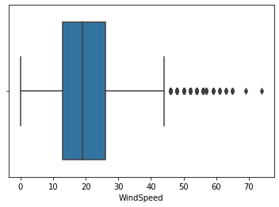

```
Humidity 1.0 100.0
```

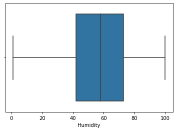

```
Pressure 977.1 1037.8
```

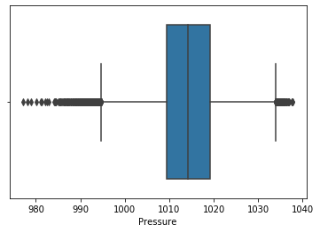

```
Cloud nan nan
```

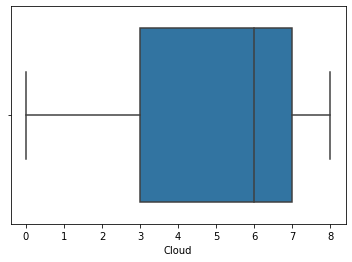

```
Temp 1.7 46.1
```

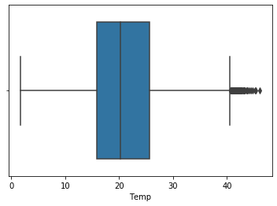

```python
for col in csv_data.columns:
    if csv_data[col].dtypes == np.float64:
        print(col , min(csv_data[col]), max(csv_data[col]))
        sb.boxplot(x=col, data = csv_data)
        plt.show()
```

After analysing the maximum and minimum values for MinTemp, MaxTemp, Evaporation, Rainfall, WindSpeed and Temprature we conclude that there are a few outliers to this data. These values are actually possible and don't need to be removed however there occurence are occasional. Thus, it would be a better choice to replace Na values for these columns with their median values

```python
for col in csv_data.columns:
    if csv_data[col].dtypes == np.float64:
        csv_data[col].fillna(csv_data[col].median(), inplace = True)
```

```python
csv_data.isnull().sum()
```

```
Location         0
MinTemp          0
MaxTemp          0
Rainfall         0
Evaporation      0
Sunshine         0
WindGustDir      0
WindGustSpeed    0
WindDir          0
WindSpeed        0
Humidity         0
Pressure         0
Cloud            0
Temp             0
RainToday        0
RainTomorrow     0
dtype: int64
```

###### Class Distribution in Target Variable

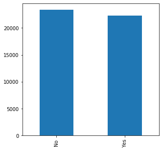

```python
plt.figure(figsize=(5,5))
csv_data['RainTomorrow'].value_counts().plot(kind='bar')
```

We can see that the target variable data dosn't contain bias

###### Plot Stacked Bar Graphs of RainToday RainTommorow, Cloud RainTommorow and WindGustDir and RainToday

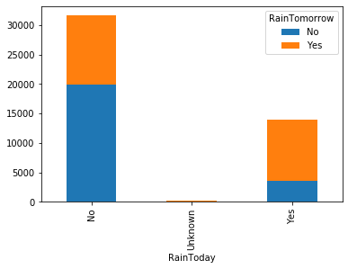

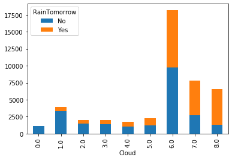

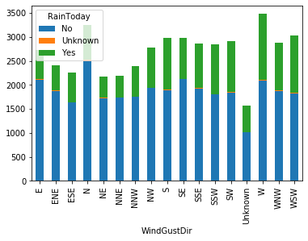

```python
pd.crosstab(csv_data['RainToday'], csv_data['RainTomorrow']).plot(kind='bar', stacked=True)
pd.crosstab(csv_data['Cloud'], csv_data['RainTomorrow']).plot(kind='bar', stacked=True)
pd.crosstab(csv_data['WindGustDir'], csv_data['RainToday']).plot(kind='bar', stacked=True)
```

As we can see from the above plot diagram there are almost 60% cases of no rainfall tommorow if it didn't rain today and more than 75% cases of rain tommorow if it rains today.

Aditionally, We can't seem to formulate a solid relation about WindGustDirection and RainToday

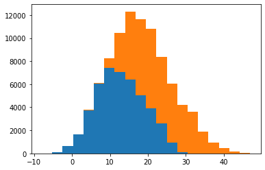

```python
plt.figure()
plt.hist([csv_data['MinTemp'],csv_data['MaxTemp']],20, stacked=True)
plt.show()
```

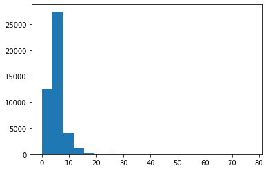

```python
plt.hist(csv_data['Evaporation'],bins =20)
```

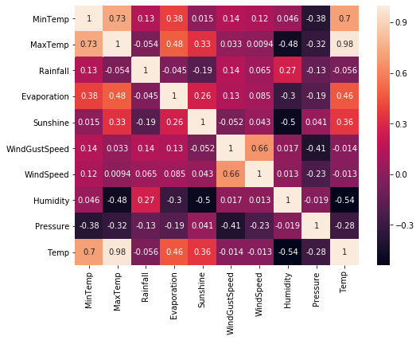

```python
plt.figure(figsize=(8,6))
df_small = csv_data[['Location','MinTemp','MaxTemp','Rainfall','Evaporation','Sunshine','WindGustSpeed','WindSpeed','Humidity','Pressure','Temp' ]]
correlation_mat = df_small.corr()

sb.heatmap(correlation_mat, annot = True)
```

The correlation matrix for all numeric features shows that MaxTemp and Temp are highly correlated with a correlation coefficent of 0.98 and so are MaxTemp and MinTemp with coefficent of 0.73. Thus, if the model takes too long to run we can use just MaxTemp as a feature insted of choosing all three of them.

###### Data preprocessing

The K-means Clustering Algorithm, HAC, and Decision Tree all work on Numeric Data. Thus, it is important to create dummy variables or one hot encoders for categorical data.

Also, the data in the numeric columns have large differences in ranges. As K-means is a distance based algorithm large values can cause greater distances even if the instances belong to the same cluster thus, it would be better to scale the Numeric values

To test the overfitting data for a particular model the data has been split into training dataset and testing dataset.

```python
y = csv_data['RainTomorrow']
X = csv_data.drop(['RainTomorrow'],axis=1)
le = LabelEncoder()
y = le.fit_transform(y)
y = pd.Series(y)
X_train, X_test , y_train, y_test = train_test_split(X,y,test_size=0.3,stratify =y)
num_features = [x for x in X.columns if csv_data[x].dtypes==np.float64]
cat_features = [x for x in X.columns if csv_data[x].dtypes!=np.float64]
categorical_transformer = Pipeline(steps=[("ohe",OneHotEncoder(sparse = False,handle_unknown='ignore'))])
numeric_transformer = Pipeline(steps=[("mms",MinMaxScaler())])
preprocessor = ColumnTransformer(
    transformers=[
        ('num', numeric_transformer, num_features),
        ('cat', categorical_transformer, cat_features)])
```

```python
X_train =preprocessor.fit_transform(X_train)
X_test =preprocessor.transform(X_test)
```

After data transformation there are a total of 89 features in the training dataset. Not all of them are important in predicting clusters. Aditionally, K-means being a distance based algoritm might not perform well dummy data. So it is important to perform Dimensionality Reduction and thus, transform data using PCA. After combinations of feature values I found out that kmeans performs best with 13 features and thus 13 features have been selected

```python
from sklearn.decomposition import PCA
pca = PCA(n_components =13)
pca.fit(X_train)
X_train_c = pca.transform(X_train)
X_test_c = pca.transform(X_test)
```

The Hyperparameters for K-means models n_init :Number of time the k-means algorithm will be run with different centroid seeds and max_iter: Maximum number of iterations of the k-means algorithm for a single run

```python
kmeans = KMeans(n_clusters=2)
param_grid = {
              'n_init': [5, 10, 20],
              'max_iter': [50, 100, 300, 500]
}
grid_k = GridSearchCV(kmeans, param_grid, cv=3, scoring='fowlkes_mallows_score',return_train_score='nmi',refit=True)
grid_k.fit(X_train_c,y_train)
```

```
GridSearchCV(cv=3, error_score='raise-deprecating',
             estimator=KMeans(algorithm='auto', copy_x=True, init='k-means++',
                              max_iter=300, n_clusters=2, n_init=10,
                              n_jobs=None, precompute_distances='auto',
                              random_state=None, tol=0.0001, verbose=0),
             iid='warn', n_jobs=None,
             param_grid={'max_iter': [50, 100, 300, 500],
                         'n_init': [5, 10, 20]},
             pre_dispatch='2*n_jobs', refit=True, return_train_score='nmi',
             scoring='fowlkes_mallows_score', verbose=0)
```

```python
print("Training accuracy for best model of K-means is:", grid_k.best_score_)


print("Best Hyperparameters")
for hps, values in grid_k.best_params_.items():
    print(f"{hps}: {values}")

print("Datafrane of accuracies obtained with each combination of hyperparameters  ")
pd.DataFrame(grid_k.cv_results_)
```

```
Training accuracy for best model of K-means is: 0.5865377434642325
Best Hyperparameters
max_iter: 50
n_init: 5
Datafrane of accuracies obtained with each combination of hyperparameters
```

|  | mean_fit_time | std_fit_time | mean_score_time | std_score_time | param_max_iter | param_n_init | params | split0_test_score | split1_test_score | split2_test_score | mean_test_score | std_test_score | rank_test_score | split0_train_score | split1_train_score | split2_train_score | mean_train_score | std_train_score |
| --- | --- | --- | --- | --- | --- | --- | --- | --- | --- | --- | --- | --- | --- | --- | --- | --- | --- | --- |
| 0 | 0.057748 | 0.000705 | 0.002700 | 0.000389 | 50 | 5 | {'max_iter': 50, 'n_init': 5} | 0.586464 | 0.585409 | 0.587741 | 0.586538 | 0.000953 | 1 | 0.58658 | 0.587118 | 0.585944 | 0.586547 | 0.00048 |
| 1 | 0.087509 | 0.008186 | 0.002303 | 0.000034 | 50 | 10 | {'max_iter': 50, 'n_init': 10} | 0.586464 | 0.585409 | 0.587741 | 0.586538 | 0.000953 | 1 | 0.58658 | 0.587118 | 0.585944 | 0.586547 | 0.00048 |
| 2 | 0.173924 | 0.016870 | 0.002346 | 0.000018 | 50 | 20 | {'max_iter': 50, 'n_init': 20} | 0.586464 | 0.585409 | 0.587741 | 0.586538 | 0.000953 | 1 | 0.58658 | 0.587118 | 0.585944 | 0.586547 | 0.00048 |
| 3 | 0.049115 | 0.001883 | 0.002327 | 0.000024 | 100 | 5 | {'max_iter': 100, 'n_init': 5} | 0.586464 | 0.585409 | 0.587741 | 0.586538 | 0.000953 | 1 | 0.58658 | 0.587118 | 0.585944 | 0.586547 | 0.00048 |
| 4 | 0.086461 | 0.006510 | 0.002313 | 0.000012 | 100 | 10 | {'max_iter': 100, 'n_init': 10} | 0.586464 | 0.585409 | 0.587741 | 0.586538 | 0.000953 | 1 | 0.58658 | 0.587118 | 0.585944 | 0.586547 | 0.00048 |
| 5 | 0.162456 | 0.013636 | 0.002317 | 0.000013 | 100 | 20 | {'max_iter': 100, 'n_init': 20} | 0.586464 | 0.585409 | 0.587741 | 0.586538 | 0.000953 | 1 | 0.58658 | 0.587118 | 0.585944 | 0.586547 | 0.00048 |
| 6 | 0.052528 | 0.006499 | 0.002341 | 0.000016 | 300 | 5 | {'max_iter': 300, 'n_init': 5} | 0.586464 | 0.585409 | 0.587741 | 0.586538 | 0.000953 | 1 | 0.58658 | 0.587118 | 0.585944 | 0.586547 | 0.00048 |
| 7 | 0.086364 | 0.006483 | 0.002289 | 0.000082 | 300 | 10 | {'max_iter': 300, 'n_init': 10} | 0.586464 | 0.585409 | 0.587741 | 0.586538 | 0.000953 | 1 | 0.58658 | 0.587118 | 0.585944 | 0.586547 | 0.00048 |
| 8 | 0.180282 | 0.015903 | 0.002334 | 0.000020 | 300 | 20 | {'max_iter': 300, 'n_init': 20} | 0.586464 | 0.585409 | 0.587741 | 0.586538 | 0.000953 | 1 | 0.58658 | 0.587118 | 0.585944 | 0.586547 | 0.00048 |
| 9 | 0.049334 | 0.007689 | 0.002330 | 0.000009 | 500 | 5 | {'max_iter': 500, 'n_init': 5} | 0.586464 | 0.585409 | 0.587741 | 0.586538 | 0.000953 | 1 | 0.58658 | 0.587118 | 0.585944 | 0.586547 | 0.00048 |
| 10 | 0.086882 | 0.005806 | 0.002319 | 0.000004 | 500 | 10 | {'max_iter': 500, 'n_init': 10} | 0.586464 | 0.585409 | 0.587741 | 0.586538 | 0.000953 | 1 | 0.58658 | 0.587118 | 0.585944 | 0.586547 | 0.00048 |
| 11 | 0.170603 | 0.018664 | 0.002344 | 0.000035 | 500 | 20 | {'max_iter': 500, 'n_init': 20} | 0.586464 | 0.585409 | 0.587741 | 0.586538 | 0.000953 | 1 | 0.58658 | 0.587118 | 0.585944 | 0.586547 | 0.00048 |

```python
print("Testing Accuracy for best K-means model:", fowlkes_mallows_score(grid_k.predict(X_test_c),y_test))
```

```
Testing Accuracy for best K-means model: 0.5873467530159528
```

###### HAC Clustering

A dendogram plot to visualize clusters

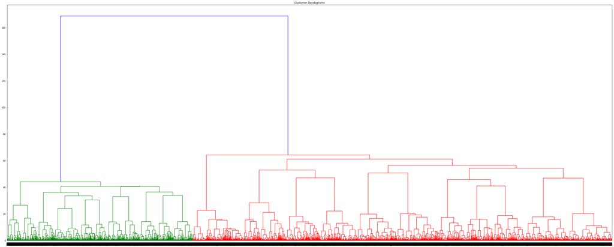

```python
import scipy.cluster.hierarchy as shc

plt.figure(figsize=(50, 20))
plt.title("Customer Dendograms")
dend = shc.dendrogram(shc.linkage(X_train_c, method='ward'))
```

The Hyperparameters for HCA clustering was the affinity and linkage which is eucledian in default case and have been tuned to l1 norm and complete to test if the model perfroms better. complete or maximum linkage uses the maximum distances between all observations of the two sets.ward minimizes the variance of the clusters being merged.

```python
hac_ward = AgglomerativeClustering()
hac_ward.fit(X_train_c,y_train)

hac_complete = AgglomerativeClustering(affinity="l1",linkage="complete")
hac_complete.fit(X_train_c,y_train)


print("Training Accuracy for ward method:",fowlkes_mallows_score(hac_ward.fit_predict(X_train_c),y_train))
print("Training Accuracy for complete method:",fowlkes_mallows_score(hac_complete.fit_predict((X_train_c)),y_train))
```

```
Training Accuracy for ward method: 0.5864230243243818
Training Accuracy for complete method: 0.5284671565605606
```

```python
print("Testing Accuracy for ward method:",fowlkes_mallows_score(hac_ward.fit_predict(X_test_c),y_test))
print("Testing Accuracy for complete method:",fowlkes_mallows_score(hac_complete.fit_predict((X_test_c)),y_test))
```

```
Testing Accuracy for ward method: 0.5874495656773543
Testing Accuracy for complete method: 0.6182978013390411
```

We can use Unsupervised Learning Algorithms such as K Means Clustering and Hirerarchical clustering as prediction algorithms. We can divide the data into clusters equal to the number of classes. For these algorithms I have used fowlkes_mallows_scorewhich is the geometric mean between of the precision and recall. FMI = TP / sqrt((TP + FP) * (TP + FN))

###### Decision Tree

It is not imporatant to perform PCA on decision tree model thus, the training data used for DT contains all 89 features

```python
from sklearn.tree import DecisionTreeClassifier
dt = DecisionTreeClassifier()
```

```python
param_grid = {'criterion': ['gini', 'entropy'],
              'min_samples_split': [2, 10, 20],
              'max_depth': [5, 10, 15, 20],
              'min_samples_leaf': [1, 3, 5,10],
              'max_leaf_nodes': [5, 10, 20, 30]}
grid = GridSearchCV(dt, param_grid, cv=3, scoring='accuracy')
grid.fit(X_train, y_train)
```

```
GridSearchCV(cv=3, error_score='raise-deprecating',
             estimator=DecisionTreeClassifier(class_weight=None,
                                              criterion='gini', max_depth=None,
                                              max_features=None,
                                              max_leaf_nodes=None,
                                              min_impurity_decrease=0.0,
                                              min_impurity_split=None,
                                              min_samples_leaf=1,
                                              min_samples_split=2,
                                              min_weight_fraction_leaf=0.0,
                                              presort=False, random_state=None,
                                              splitter='best'),
             iid='warn', n_jobs=None,
             param_grid={'criterion': ['gini', 'entropy'],
                         'max_depth': [5, 10, 15, 20],
                         'max_leaf_nodes': [5, 10, 20, 30],
                         'min_samples_leaf': [1, 3, 5, 10],
                         'min_samples_split': [2, 10, 20]},
             pre_dispatch='2*n_jobs', refit=True, return_train_score=False,
             scoring='accuracy', verbose=0)
```

```python
print("Training Accuracy for best Decision Tree model: ",grid.best_score_)

print("Best Hyperparameters")
for hps, values in grid.best_params_.items():
    print(f"{hps}: {values}")
```

```
Training Accuracy for best Decision Tree model:  0.7710662752201887
Best Hyperparameters
criterion: entropy
max_depth: 10
max_leaf_nodes: 30
min_samples_leaf: 1
min_samples_split: 2
```

```python
print("Dataframe of accuracies obtained with each combination of hyperparameters  ")
pd.DataFrame(grid.cv_results_)
```

[output not shown]

|  | mean_fit_time | std_fit_time | mean_score_time | std_score_time | param_criterion | param_max_depth | param_max_leaf_nodes | param_min_samples_leaf | param_min_samples_split | params | split0_test_score | split1_test_score | split2_test_score | mean_test_score | std_test_score | rank_test_score |
| --- | --- | --- | --- | --- | --- | --- | --- | --- | --- | --- | --- | --- | --- | --- | --- | --- |
| 0 | 0.080855 | 0.003641 | 0.002915 | 0.000378 | gini | 5 | 5 | 1 | 2 | {'criterion': 'gini', 'max_depth': 5, 'max_lea... | 0.746088 | 0.740092 | 0.738849 | 0.741677 | 0.003161 | 337 |
| 1 | 0.064710 | 0.001845 | 0.002174 | 0.000015 | gini | 5 | 5 | 1 | 10 | {'criterion': 'gini', 'max_depth': 5, 'max_lea... | 0.746088 | 0.740092 | 0.738849 | 0.741677 | 0.003161 | 337 |
| 2 | 0.062134 | 0.001128 | 0.002187 | 0.000014 | gini | 5 | 5 | 1 | 20 | {'criterion': 'gini', 'max_depth': 5, 'max_lea... | 0.746088 | 0.740092 | 0.738849 | 0.741677 | 0.003161 | 337 |
| 3 | 0.071809 | 0.001519 | 0.002775 | 0.000235 | gini | 5 | 5 | 3 | 2 | {'criterion': 'gini', 'max_depth': 5, 'max_lea... | 0.746088 | 0.740092 | 0.738849 | 0.741677 | 0.003161 | 337 |
| 4 | 0.067283 | 0.003521 | 0.002259 | 0.000159 | gini | 5 | 5 | 3 | 10 | {'criterion': 'gini', 'max_depth': 5, 'max_lea... | 0.746088 | 0.740092 | 0.738849 | 0.741677 | 0.003161 | 337 |
| ... | ... | ... | ... | ... | ... | ... | ... | ... | ... | ... | ... | ... | ... | ... | ... | ... |
| 379 | 0.112600 | 0.000422 | 0.002821 | 0.000010 | entropy | 20 | 30 | 5 | 10 | {'criterion': 'entropy', 'max_depth': 20, 'max... | 0.780099 | 0.766888 | 0.766211 | 0.771066 | 0.006393 | 1 |
| 380 | 0.113015 | 0.002301 | 0.002867 | 0.000048 | entropy | 20 | 30 | 5 | 20 | {'criterion': 'entropy', 'max_depth': 20, 'max... | 0.780099 | 0.766888 | 0.766211 | 0.771066 | 0.006393 | 1 |
| 381 | 0.111748 | 0.001754 | 0.002830 | 0.000049 | entropy | 20 | 30 | 10 | 2 | {'criterion': 'entropy', 'max_depth': 20, 'max... | 0.780099 | 0.766888 | 0.766211 | 0.771066 | 0.006393 | 1 |
| 382 | 0.111699 | 0.002289 | 0.002883 | 0.000049 | entropy | 20 | 30 | 10 | 10 | {'criterion': 'entropy', 'max_depth': 20, 'max... | 0.780099 | 0.766888 | 0.766211 | 0.771066 | 0.006393 | 1 |
| 383 | 0.112955 | 0.002689 | 0.003077 | 0.000296 | entropy | 20 | 30 | 10 | 20 | {'criterion': 'entropy', 'max_depth': 20, 'max... | 0.780099 | 0.766888 | 0.766211 | 0.771066 | 0.006393 | 1 |

384 rows × 16 columns

```python
from sklearn.metrics import classification_report
print("Classification report:",classification_report(grid.predict(X_test),y_test))
```

```
Classification report:               precision    recall  f1-score   support

           0       0.79      0.76      0.78      7252
           1       0.74      0.77      0.76      6470

    accuracy                           0.77     13722
   macro avg       0.77      0.77      0.77     13722
weighted avg       0.77      0.77      0.77     13722
```

```
0.8497657287797465
```

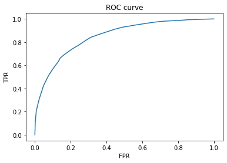

```python
from sklearn.metrics import roc_auc_score
from sklearn.metrics import roc_curve
predictions = grid.predict_proba(X_test)

print(roc_auc_score(y_test, predictions[:,1]))

fpr, tpr, _ = roc_curve(y_test, predictions[:,1])

plt.clf()
plt.plot(fpr, tpr)
plt.xlabel('FPR')
plt.ylabel('TPR')
plt.title('ROC curve')
plt.show()
```

The AUC score for best estimators is 0.8497657287797465

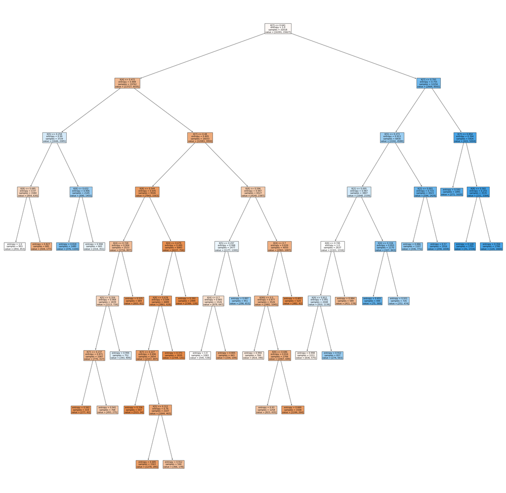

```python
from sklearn import tree
fig = plt.figure(figsize=(45,45))
d_=tree.plot_tree(grid.best_estimator_,
               filled=True)
```

The tree visualization of best performing estimator

###### Get Predictions for testing csv file

```python
test_data = pd.read_csv('Weather Forecast Testing.csv')
```

```python
test_data.isnull().sum()
```

```
ID                  0
Location            0
MinTemp            47
MaxTemp            18
Rainfall          161
Evaporation      5516
Sunshine         6094
WindGustDir       929
WindGustSpeed     920
WindDir           387
WindSpeed         261
Humidity          349
Pressure         1293
Cloud            5020
Temp              267
RainToday         161
dtype: int64
```

```python
test_data[['WindGustDir', 'WindDir','RainToday']] = test_data[['WindGustDir','WindDir','RainToday']].fillna(value='Unknown')
for col in test_data.columns:
    if test_data[col].dtypes == np.float64:
        test_data[col].fillna(csv_data[col].median(), inplace = True)
```

Prediction for Clustering

```python
test_data_c = preprocessor.transform(test_data)
test_data_c = pca.transform(test_data_c)

kmeans = grid_k.predict(test_data_c)
HAC = hac_complete.fit_predict(test_data_c)
```

```python
test_data_d = preprocessor.transform(test_data)

DT = grid.predict(test_data_d)
```

```python
pred_dataframe = pd.DataFrame({"ID":test_data.index,
                              "kmeans":kmeans,
                              "HAC":HAC,
                              "DT":DT})
```

```python
pred_dataframe.to_csv('prediction.csv',index=False)
```